# STAT 240: Project

# Introduction

Drug usage and overdose are critical public health challenges, with nearly 100,000 people dying annually from drug overdoses in the United States (“Drug Overdose Death Statistics [2023]”). Understanding patterns of substance consumption across different age groups can provide crucial insights to guide prevention and intervention efforts.

This analysis focuses specifically on what the regular alcohol consumption across age groups is and examines trends to identify which age groups require the most attention in public health initiatives.

The findings reveal that alcohol is one of the most commonly consumed substances among individuals aged 18-24. While other substances like caffeine and chocolate are also widely consumed, this analysis centers on alcohol due to its significant public health implications. Overall we found that alcohol consumption decreases significantly with increased age as the data is further analyzed.

# Background

In order to answer our question, we need to know how much alcohol is being consumed by each age group from age 18 to 65 and up. The age groups consist of six age groups:

- 18-24
- 24-35
- 35-44
- 45-54
- 55-64
- 65+

Our data set consists of data from one source that had this information.

## Age and Drug Use Data (https://doi.org/10.24432/C5TC7S)

The Age column quantified the ages of all individuals so that each row or individual had a value across a broad range between -0.95 and 2.59, that would put them in a certain age group. For example the value -0.95197 puts that individual into the age group 18-24 where 1.09449 puts them into 45-59. The Alcohol column placed each individual into one of 7 classes based on the frequency of their consumption. The classes included:

- CLO: never used
- CL1: used over a decade ago
- CL2: used in the last decade
- CL3: used in the last year
- CL4: used in the last month
- CL5: used in the last week
- CL6 used in the last day.

## Combined Data

These columns or features can be joined together in a separate table, grouping individuals by their respective age group, and then a statistical analysis can be conducted to see if alcohol consumption varies among age groups.

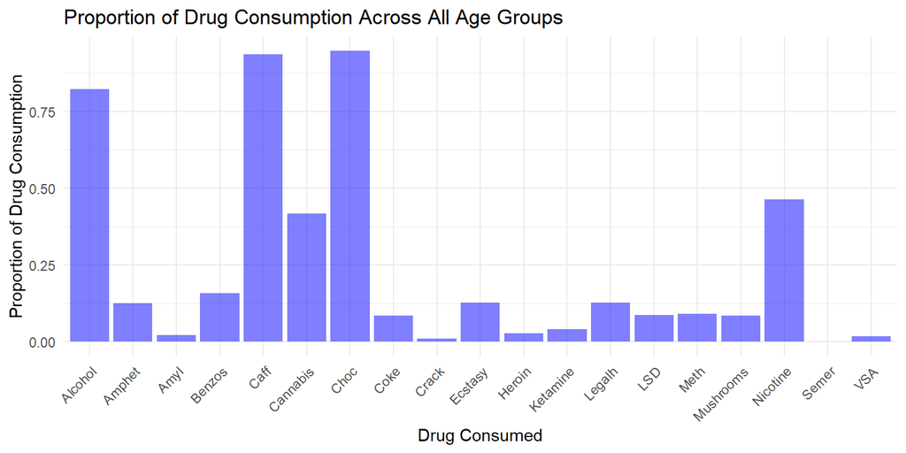

# Statistical Analysis

## Initial Thoughts

- First, we will set up a graph to take a look at the proportion of people that drink within each age group.

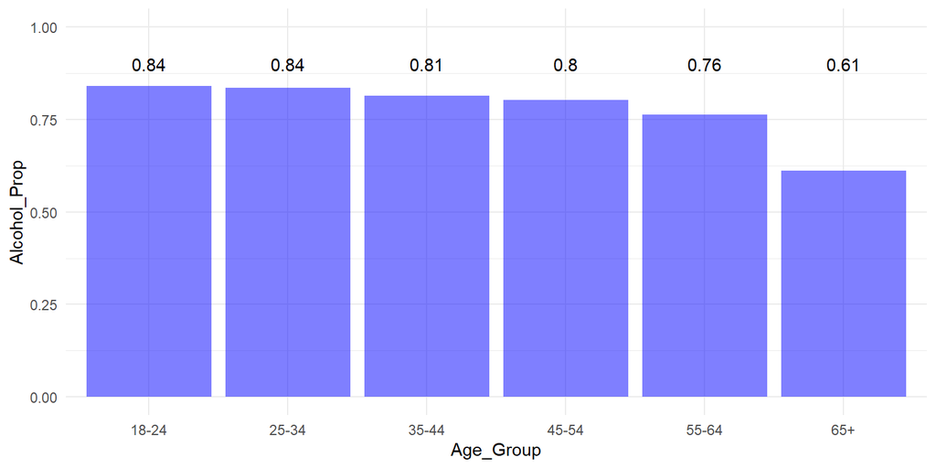

> From the graph we can see a clear and intuitive downward trend in alcohol consumption as age increases, but we will have to do a statistical analysis to say this conclusively.

## Statistical Model

We wish to explore if the average proportion of drinkers changes between age groups. To do this we will let:

- $X_i$ represent the statistical model of regular drinkers for $i$ age group.
- $n_i$ represent the total number of cases for each age group.
- $p_i$ represent the true proportion of drinkers for each age group.
- $i$ represent the the groups with $1$ being ages 18-24, $2$ being 25-34, etc.

and we will use these models.

$$X_1 \sim \text{Binom}(n_1, p_1) \\
X_2 \sim \text{Binom}(n_2, p_2) \\
X_3 \sim \text{Binom}(n_3, p_3) \\
X_4 \sim \text{Binom}(n_4, p_4) \\
X_5 \sim \text{Binom}(n_5, p_5) \\
X_6 \sim \text{Binom}(n_6, p_6)$$

We will assume that the BINS assumptions are met for each model as such:

- B: Each case is binomial, either a regular drinker or a non-regular drinker.
- I: Each case is independent from each other.
- N: The number of cases is predetermined.
- S: The probability for each case remains the same.

The assumption of independence could potentially not be met since drinking tends to be a social activity, thus one regular drinker could affect another person.

## Hypothesis

- With these models we will begin conducting the testing of the hypothesis

$$H_0 : X_1 - X_2 \text{ through } X_6 = 0$$
$$H_a : X_1 - X_2 \text{ through } X_6 > 0$$
using a two-sample z-test for a difference in proportions.

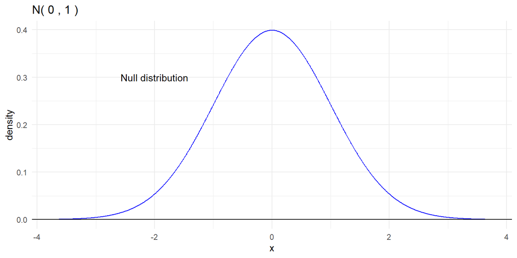

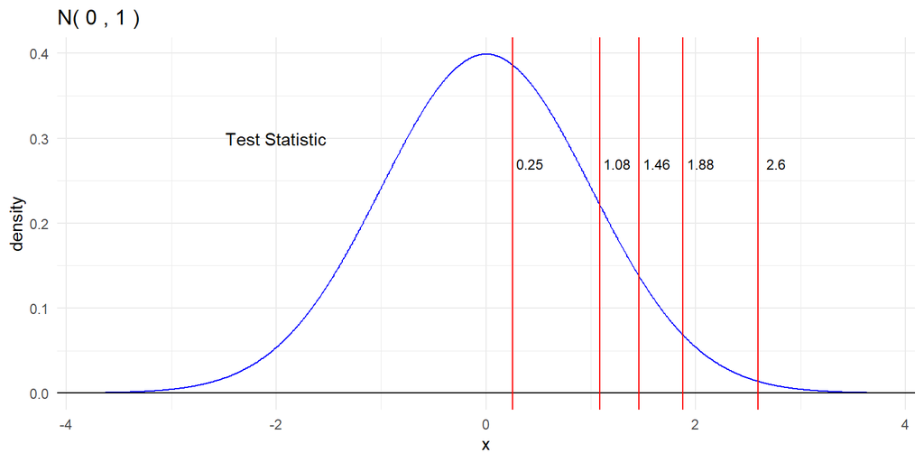

#### Significance Between Age Group 18-24 and other Age Groups

```
## # A tibble: 5 × 3
##   Age_comparison p_value significant
##   <chr>            <dbl> <lgl>
## 1 18-24 to 25-34 0.800   FALSE
## 2 18-24 to 35-44 0.279   FALSE
## 3 18-24 to 45-54 0.145   FALSE
## 4 18-24 to 55-64 0.0606  FALSE
## 5 18-24 to 65+   0.00942 TRUE
```

## Interpretation

> We fail to find significant evidence that the probability of people consuming alcohol is different between age group 18-24 and each other age group, EXCEPT age group 65+ (p = 0.00942), using a standard significance score of p = 0.05. However, for age group 54-65, there is some potential significance because the p-score was 0.06056

### The Relationship Between Age Group and Alcohol Consumption Proportion

#### Forumla Using a Linear Regression Model

$$AlcoholConsumptionProp=0.91618−0.03943⋅AgeGroup+ϵ$$

$$Intercept(\beta_0) = 0.91618$$
$$Slope (\beta_1) = 0.03943$$

$$R^2 = 0.7282$$
$$R^2 (adjusted) = 0.6603$$

$$Confidence Interval (\beta_1) =
(-0.0729, -0.0060)$$
$$\epsilon =
residualError$$

$$p\_value = 0.0307$$

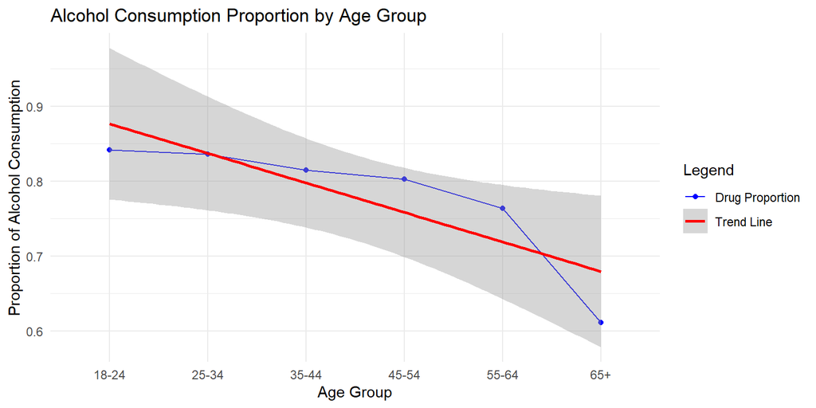

# Discussion

Multiple limitations due to the data were identified in our analysis. First, the sampled population had a few biases, namely education and racial ones. Over 90% of participants reported being white, and 59.5% of participants had at least a degree or professional certification. The data also reported the age of participants in ranges, as noted in the background section, as opposed to specific ages, and limited the data to people 18 and older, potentially hiding any trends for any age group more specific than the given ranges.

Two assumptions of the binomial model were also not met, those being the “same probability” assumption, and the “set sample size” assumption. Whether or not each individual had the same probability of consuming alcohol was the focus of the analysis, and so could not be an assumption when selecting the model. As for the sample size, the data was collected through an open online survey, the sample size was not fixed, and just depended on how many people took the survey before it was closed.

Additional analysis could be done investigating whether any of the other drugs with data reported for them have an age bias, or whether trends in any of the other participant characteristics; such as gender, education, or ethnicity; show a trend.

# References

1. “Drug Overdose Death Statistics [2023]: Opioids, Fentanyl & More.” NCDAS. N.p., n.d. Web. 2 Dec. 2024, https://drugabusestatistics.org/drug-overdose-deaths/.
2. Fehrman, Elaine, Vincent Egan, and Evgeny Mirkes. “Drug Consumption (Quantified).” UCI Machine Learning Repository, 2015, https://doi.org/10.24432/C5TC7S.